# Projekt 2 – Model CreditMetrics

Modelowanie ryzyka kredytowego i operacyjnego (NS)

Aleksandra Konopelska

25.04.2026

# 1 Cel projektu

## 1.1 Zadanie teoretyczne

- Wyjaśnić pojęcie ratingów – jakie poziomy ratingów stosują najbardziej znane agencje ratingowe?
- Wyjaśnić ideę modelu CreditMetrics – na czym on bazuje i w jaki sposób opisuje ryzyko kredytowe?

## 1.2 Zadania praktyczne

1. Z wykorzystaniem modelu CreditMetrics wyznaczyć 99,9% VaR i ES dla portfela składającego się z trzech obligacji skarbowych:
   - 3-letnia obligacja o ratingu BBB (cena wykupu 100 000 zł, subordinated),
   - 5-letnia obligacja o ratingu B (cena wykupu 50 000 zł, senior secured),
   - 2-letnia obligacja o ratingu CCC (cena wykupu 50 000 zł, senior unsecured).
2. Opisać kolejne kroki rozwiązywanego zadania.
3. Zbadać, w jaki sposób zmieniłyby się wyniki, jeśli założylibyśmy, że inwestycje w portfelu są skorelowane (tj. współczynniki korelacji między inwestycjami w portfelu wynoszą: r12 = 0.2, r13 = 0.15, r23 = 0.4). Jak uzyskane wyniki łączą się z pojęciem dywersyfikacji ryzyka?
4. Na podstawie dokumentacji technicznej CreditMetrics opisać, jakie są sposoby wyznaczania korelacji w modelu.

# 2 Część teoretyczna

## 2.1 Wyjaśnić pojęcie ratingów, jakie poziomy ratingów stosują najbardziej znane agencje ratingowe?

**Rating** to ocena wiarygodności kredytowej emitenta (instytucja, firma, bank, jednostka samorządu terytorialnego lub państwo), który zaciąga dług, sprzedając obligacje inwestorom), innymi słowy miara ryzyka związanego z inwestycją w jego papiery dłużne. Wystawiany jest przez agencję ratingową na podstawie oceny ryzyka ekonomicznego, politycznego i społecznego.

Agencje ratingowe są **„obiektywnym”** i **stabilnym** źródłem wiedzy o ryzyku inwestycji. Obiektywność oznacza, że żadna firma ani kraj nie może zmusić agencji do wystawienia lepszej oceny, agencja decyduje samodzielnie, bez zewnętrznych nacisków (przynajmniej w teorii). Stabilność zaś oznacza, że oceny nie zmieniają się zbyt często: każda zmiana ratingu niesie za sobą określone konsekwencje, dlatego agencje zmieniają wcześniej ustaloną ocenę tylko wtedy, gdy zajdzie naprawdę istotne wydarzenie.

Istnieją trzy główne agencje ratingowe: **Moody’s**, **Fitch** oraz **Standard & Poor’s**. Razem kontrolują ponad 90% rynku ratingów, a ich głównym zadaniem jest ocena jakości obligacji wystawianych przez duże przedsiębiorstwa i kraje. Oceny wszystkich trzech agencji są porównywalne, choć każda z nich stosuje nieco inną notację.

Skala ocen S&P i Fitch zaczyna się od najlepszej oceny **AAA**, a następnie mamy **AA**, **A**, **BBB**, **BB**, **B** i **CCC**. Symbol **D** oznacza bankructwo (niewypłacalność). Dodatkowo istnieją oceny pośrednie, np. AA-, BBB+ itp. Agencja Moody’s zapisuje te same poziomy nieco inaczej: **Aaa**, **Aa**, **A**, **Baa**, **Ba**, **B** i **Caa**. Oceny wszystkich trzech agencji są porównywalne.

Wystawiane oceny można podzielić na dwie kategorie:

- **Standard inwestycyjny** – obligacje z małym prawdopodobieństwem niewypłacalności. Kupujący godzi się na niewielką stopę zwrotu, bo ryzyko jest małe (mało ryzyka, mały zysk).
- **Standard spekulacyjny**, czyli tzw. **obligacje śmieciowe** – inwestor jest kuszony wysokim oprocentowaniem, rozumiejąc jednocześnie, że taka inwestycja jest ryzykowna.

## 2.2 Wyjaśnić ideę modelu CreditMetrics. Na czym on bazuje i w jaki sposób opisuje ryzyko kredytowe?

**CreditMetrics** to model stworzony w **1997 roku** przez bank **J.P. Morgan**, prezentujący nieco inne podejście do pomiaru ryzyka kredytowego. Opiera się on na **ratingach kredytowych** (ocenach wiarygodności kredytowej emitenta wystawianych przez agencje ratingowe, np. AAA, BBB, CCC) i na ich podstawie mierzy zarówno **ryzyko niewypłacalności**, jak i **ryzyko pogorszenia wiarygodności kredytowej**, czyli bierze pod uwagę pełny zakres **migracji ratingowych** (zarówno w górę, jak i w dół skali), a nie tylko samo bankructwo. CreditMetrics jest jednym z niewielu modeli, które mierzą ryzyko kredytowe **całego portfela**, a nie tylko pojedynczej obligacji. Liczy on rozkład wartości portfela na koniec przyjętego okresu, a prawdopodobieństwa każdej zmiany ratingu bierze z **macierzy przejścia** (tabeli, która pokazuje, z jakim prawdopodobieństwem obligacja o danym ratingu w ciągu roku zmieni go na inny, np. z BBB przejdzie na A albo na CCC). W portfelu mogą znaleźć się też inne instrumenty finansowe, nie tylko obligacje.

Model CreditMetrics bazuje na kilku elementach wejściowych, które w większości wyznacza się na podstawie **danych historycznych**:

1. **Kategorie ratingowe**: np. skala S&P: AAA, AA, A, BBB, BB, B, CCC oraz stan **Default**. Ratingi kredytowe stanowią podstawowy opis jakości kredytowej emitenta.
2. **Macierz przejścia (transition matrix)**: tabela, która pokazuje, z jakim prawdopodobieństwem obligacja o danym ratingu zmieni po roku rating na inny (np. z BBB przejdzie na A, CCC albo trafi do niewypłacalności).
3. **Krzywa forward zero**: (na wykładzie mówi się o niej jako o **stopie procentowej / stopie zwrotu dla obligacji o danym ratingu**) - inna dla każdego ratingu. Dzięki niej możemy obliczyć, ile obligacja będzie warta po roku, jeśli nie zbankrutowała.
4. **Stopa odzysku (recovery rate)**: określa wartość obligacji w przypadku **niewypłacalności**; zależy od **jakości obligacji**.
5. **Macierz korelacji między inwestycjami w portfelu kredytowym**: uwzględnia, że zmiany ratingów różnych obligacji w portfelu są ze sobą powiązane.

Model opisuje ryzyko kredytowe konstruując **rozkład wartości portfela** (zestawienie, jakie wartości portfel może przyjąć i z jakimi prawdopodobieństwami) na przyjętym **horyzoncie czasowym** (np. 1 rok). Inaczej mówiąc: dla każdego możliwego scenariusza zmian ratingów obligacji w portfelu liczy, ile portfel będzie wart, oraz z jakim prawdopodobieństwem ten scenariusz się zdarzy. Mając taki rozkład, policzyć można miary ryzyka: **kwantyl (VaR)** (wartość, poniżej której portfel spadnie tylko w rzadkich scenariuszach, np. w 0,1% przypadków) oraz **odchylenie standardowe** (miara tego, jak mocno wartości portfela rozrzucają się wokół średniej).

**Dla pojedynczej obligacji**:

1. Z wiersza **macierzy przejścia** odpowiadającego ratingowi początkowemu obligacji odczytujemy prawdopodobieństwa przejścia do każdego możliwego ratingu (również do niewypłacalności).
2. W każdym z tych scenariuszy wyceniamy obligację na koniec roku,
3. korzystamy ze **stopy zwrotu** dla nowego ratingu (rentowności obligacji danej klasy ratingowej), a w przypadku niewypłacalności ze **stopy odzysku** (jaką część wartości obligacji inwestor odzyskuje, gdy emitent zbankrutuje).
4. Mając rozkład możliwych wartości obligacji, liczymy **99,9% kwantyl (VaR)** oraz **odchylenie standardowe funkcji straty** (funkcja straty to różnica między obecną wartością obligacji a jej wartością w przyszłych scenariuszach).

**Dla portfela wielu obligacji** stosuje się **metodę symulacyjną** (losowanie bardzo wielu możliwych scenariuszy i sprawdzanie, co dzieje się z portfelem w każdym z nich):

1. Wyznaczamy **macierz korelacji między inwestycjami w portfelu kredytowym** (tabelę pokazującą, jak mocno zmiana ratingu jednej obligacji jest powiązana ze zmianą ratingu innej). Uwzględnienie korelacji jest ważne z punktu widzenia **dywersyfikacji** (rozkładania ryzyka na różne inwestycje, żeby jedna strata nie obciążyła całego portfela). Model zakłada **kopułę gaussowską** (matematyczny sposób łączenia rozkładów normalnych, który uwzględnia korelacje między nimi).
2. Losujemy wiele **scenariuszy** z **wielowymiarowego rozkładu normalnego** (rozkładu, w którym kilka zmiennych losowanych jest jednocześnie, a ich wzajemne zachowanie opisuje macierz korelacji).
3. Dla każdej obligacji, na podstawie odpowiedniego wiersza macierzy przejścia, wyznaczamy **przedziały liczbowe na osi liczb losowych** z **rozkładu N(0,1)** (standardowego rozkładu normalnego ze średnią 0 i odchyleniem 1). Każdy przedział odpowiada jednemu z możliwych ratingów końcowych.
4. W każdym scenariuszu wylosowaną liczbę zamieniamy na rating końcowy obligacji (zgodnie z przedziałami), wyceniamy każdą obligację i sumujemy, otrzymując **wartość portfela na koniec roku**.
5. Po wielu tysiącach scenariuszy mamy rozkład wartości portfela i liczymy z niego **odpowiedni kwantyl (VaR)** oraz odchylenie standardowe.

# 3 Część praktyczna

W tej części wykonam cztery zadania:

1. **Policzę 99,9% VaR i ES** dla portfela trzech obligacji (opisanych w tabeli niżej) przy użyciu modelu CreditMetrics.
2. **Opiszę kolejne kroki** rozwiązania. Kroki to:
   - wczytanie danych (macierz przejścia, stopy forward zero, stopy odzysku) z pliku `dane_cm.xlsx`,
   - wycena każdej obligacji w każdym możliwym ratingu końcowym po 1 roku,
   - wyznaczenie progów na osi N(0,1) dla każdej obligacji (na podstawie wiersza macierzy przejścia),
   - symulacja Monte Carlo - wylosowanie wielu scenariuszy z wielowymiarowego rozkładu normalnego,
   - dla każdego scenariusza: zamiana liczb losowych na ratingi końcowe i wycena całego portfela,
   - obliczenie 99,9% **VaR** i **ES** z rozkładu wartości portfela.
3. **Zbadam, jak zmienią się wyniki**, jeśli założę, że obligacje w portfelu są ze sobą skorelowane (r₁₂ = 0,2, r₁₃ = 0,15, r₂₃ = 0,4). Wyjaśnię, jak uzyskane wyniki wiążą się z pojęciem **dywersyfikacji ryzyka**.
4. **Opiszę, jak w modelu CreditMetrics wyznacza się korelacje**, na podstawie dokumentacji technicznej CreditMetrics.

## 3.1 Dane wejściowe

Portfel trzech obligacji skarbowych:

| Nr | Rating | Termin [lata] | Cena wykupu [zł] | Uprzywilejowanie |
| --- | --- | --- | --- | --- |
| 1 | BBB | 3 | 100 000 | Subordinated |
| 2 | B | 5 | 50 000 | Senior Secured |
| 3 | CCC | 2 | 50 000 | Senior Unsecured |

**Uprzywilejowanie** = kolejność spłaty długu, jeśli emitent zbankrutuje:

- **Senior Secured**: dług zabezpieczony konkretnym majątkiem firmy (np. nieruchomością) -> wierzyciel pierwszy w kolejce do spłaty.
- **Senior Unsecured**: dług bez zabezpieczenia majątkiem, ale wciąż wyżej w kolejce niż klasa Subordinated.
- **Subordinated**: dług podporządkowany: wierzyciel ostatni w kolejce, dostaje pieniądze dopiero po spłacie klas Senior Secured i Senior Unsecured.

Od uprzywilejowania zależy **stopa odzysku** (ile inwestor dostanie z powrotem w razie bankructwa).

Obligacja może wypłacać inwestorowi pieniądze na dwa sposoby:

- **Kupon**: odsetki, które obligacja wypłaca co pewien czas (np. co roku). Jeśli obligacja ma kupon 5% i wartość 100 000 zł, to co roku inwestor dostaje 5 000 zł odsetek.
- **Cena wykupu**: kwota, którą inwestor dostaje na sam koniec, gdy obligacja się „kończy”.

W treści zadania podana jest **tylko cena wykupu**. Dlatego zakładam, że obligacje są **zerokuponowe**, czyli inwestor nie dostaje żadnych odsetek po drodze, tylko cenę wykupu na końcu (np. dla obligacji BBB, 100 000 zł po 3 latach i nic wcześniej).

### 3.1.1 Wczytanie macierzy przejścia

Model CreditMetrics potrzebuje **trzech tabel**, bo każda odpowiada za inny element obliczeń:

1. **Macierz przejścia**: mówi, z jakim **prawdopodobieństwem** obligacja zmieni po roku rating (np. BBB -> A, CCC albo Default).
2. **Stopy zwrotu**: mówią, ile obligacja będzie **warta po roku** w każdym możliwym ratingu (inna stopa dyskontowa dla AAA, inna dla A, inna dla CCC).
3. **Stopa odzysku**: mówi, ile inwestor odzyska w razie bankructwa emitenta (zależy od klasy uprzywilejowania).

Bez wszystkich trzech nie da się policzyć VaR i ES, każda dostarcza innej informacji potrzebnej w algorytmie.

Z pliku `dane_cm (4)(1).xlsx` wczytuję **tylko macierz przejścia**. Pozostałe dwie tabele są małe (7 × 4 wartości stóp zwrotu, 5 wartości stóp odzysku), więc wpisuję je ręcznie w kolejnych chunkach.

```r
library(readxl)

# col_names = TRUE => pierwszy wiersz to nagłówki (aaa, aa, ..., def)
surowe <- read_excel("dane_cm (4)(1).xlsx", sheet = 1,
                     col_names = TRUE, .name_repair = "minimal")

# lista nazw wszystkich ratingów (końcowych jest 8, łącznie z def)
ratingi <- c("AAA", "AA", "A", "BBB", "BB", "B", "CCC", "Def")

# wybieram z tabeli wiersze 1-7 (ratingi startowe) i kolumny 2-9
# (pomijam kolumnę 1, bo to etykiety wierszy, nie liczby)
# całość zamieniam na macierz liczb 7x8 i zapisuję jako macierz_przejscia
macierz_przejscia <- matrix(as.numeric(as.matrix(surowe[1:7, 2:9])),
                             nrow = 7, byrow = FALSE)

rownames(macierz_przejscia) <- ratingi[1:7]

colnames(macierz_przejscia) <- ratingi

round(macierz_przejscia, 4)
```

```
##        AAA     AA      A    BBB     BB      B    CCC    Def
## AAA 0.9340 0.0594 0.0064 0.0000 0.0002 0.0000 0.0000 0.0000
## AA  0.0161 0.9055 0.0746 0.0026 0.0009 0.0001 0.0000 0.0002
## A   0.0007 0.0228 0.9244 0.0463 0.0045 0.0012 0.0001 0.0000
## BBB 0.0005 0.0026 0.0551 0.8848 0.0476 0.0071 0.0008 0.0015
## BB  0.0002 0.0005 0.0042 0.0516 0.8691 0.0591 0.0024 0.0129
## B   0.0000 0.0004 0.0013 0.0054 0.0635 0.8422 0.0191 0.0681
## CCC 0.0000 0.0000 0.0000 0.0062 0.0205 0.0408 0.6920 0.2405
```

```r
# kontrola poprawności: każdy wiersz musi sumować się do 1
# (bo prawdopodobieństwa wszystkich scenariuszy = 100%)
rowSums(macierz_przejscia)
```

```
## AAA  AA   A BBB  BB   B CCC
##   1   1   1   1   1   1   1
```

### 3.1.2 Stopy zwrotu

```r
# wpisuję ręcznie macierz stóp zwrotu (7 ratingów x 4 lata)
# wartości skopiowane z tabeli "stopy zwrotu"
stopy <- matrix(c(
  0.0360, 0.0417, 0.0473, 0.0512,  # AAA
  0.0365, 0.0422, 0.0478, 0.0517,  # AA
  0.0372, 0.0432, 0.0493, 0.0532,  # A
  0.0410, 0.0467, 0.0525, 0.0563,  # BBB
  0.0555, 0.0602, 0.0678, 0.0727,  # BB
  0.0605, 0.0702, 0.0803, 0.0852,  # B
  0.1505, 0.1502, 0.1403, 0.1352   # CCC
), nrow = 7, byrow = TRUE)

# nazywam wiersze ratingami, kolumny Y1..Y4 (rok 1, rok 2, rok 3, rok 4)
rownames(stopy) <- ratingi[1:7]
colnames(stopy) <- paste0("Y", 1:4)

round(stopy * 100, 2)
```

```
##        Y1    Y2    Y3    Y4
## AAA  3.60  4.17  4.73  5.12
## AA   3.65  4.22  4.78  5.17
## A    3.72  4.32  4.93  5.32
## BBB  4.10  4.67  5.25  5.63
## BB   5.55  6.02  6.78  7.27
## B    6.05  7.02  8.03  8.52
## CCC 15.05 15.02 14.03 13.52
```

### 3.1.3 Stopa odzysku, a klasa obligacji

Biorę tylko średnią z tabeli, dlatego że:

- W **podstawowej wersji** modelu CreditMetrics stopa odzysku jest **stałą liczbą**, np. dla klasy Subordinated zawsze przyjmujemy 32,74%. Nie losujemy jej, więc nie potrzeba nam odchylenia.
- **Odchylenie standardowe** jest potrzebne w **rozszerzonej wersji** modelu, gdzie stopa odzysku jest **zmienną losową** z rozkładu beta. Tam średnia mówi że średnio inwestor odzyska tyle procent, a odchylenie, że może też odzyskać sporo więcej albo sporo mniej. Tej wersji nie robimy.

```r
# lista średnich stóp odzysku dla każdej klasy uprzywilejowania
# (tylko średnie - używane w obliczeniach jako stałe wartości)
odzysk <- list(
  "Senior Secured"     = 0.5380,
  "Senior Unsecured"   = 0.5113,
  "Senior Subordinated"= 0.3852,
  "Subordinated"       = 0.3274,
  "Junior Subordinated"= 0.1709
)
 odzysk
```

```
## $`Senior Secured`
## [1] 0.538
##
## $`Senior Unsecured`
## [1] 0.5113
##
## $`Senior Subordinated`
## [1] 0.3852
##
## $Subordinated
## [1] 0.3274
##
## $`Junior Subordinated`
## [1] 0.1709
```

### 3.1.4 Definicja obligacji w portfelu

```r
obligacje <- list(
  list(nazwa = "BBB 3y 100k Subordinated",
       start = "BBB", zapadalnosc = 3, FV = 100000,
       odzysk = odzysk[["Subordinated"]]),
  list(nazwa = "B 5y 50k Senior Secured",
       start = "B",   zapadalnosc = 5, FV = 50000,
       odzysk = odzysk[["Senior Secured"]]),
  list(nazwa = "CCC 2y 50k Senior Unsecured",
       start = "CCC", zapadalnosc = 2, FV = 50000,
       odzysk = odzysk[["Senior Unsecured"]])
)
```

## 3.2 Krok I Wycena obligacji pod każdym scenariuszem ratingowym

W tym kroku sprawdzam, ile każda z trzech obligacji będzie warta za rok: liczę to osobno dla każdego możliwego ratingu końcowego (AAA, AA, A, BBB, BB, B, CCC albo Default).

Dla każdej obligacji rozważam **dwie sytuacje**:

**1. Obligacja przetrwała (nie zbankrutowała)**

Biorę jej cenę wykupu $FV$ i sprawdzam, ile jest warta po 1 roku, jeśli na koniec roku obligacja ma nowy rating. Używam do tego stopy zwrotu $r$ odpowiadającej temu nowemu ratingowi (z tabeli `stopy`):

$$V = \frac{FV}{(1+r)^k}$$

gdzie $k = \text{zapadalnosc} - 1$ (ile lat jeszcze zostało do wykupu po horyzoncie 1 roku).

**2. Obligacja zbankrutowała (Default)**

Inwestor nie dostaje pełnej ceny wykupu, tylko jej część zależną od klasy uprzywilejowania (stopa odzysku $RR$):

$$V = FV \cdot RR$$

Wynik: wiersze to obligacje, kolumny to 8 możliwych ratingów końcowych. Każda komórka mówi, ile dana obligacja będzie warta po roku w tym scenariuszu.

```r
# funkcja licząca wartość obligacji po 1 roku dla zadanego ratingu końcowego
wycena_po_roku <- function(FV, zapadalnosc, rating_koncowy, odzysk) {
  # ile lat zostanie do wykupu po horyzoncie 1 roku
  lat <- zapadalnosc - 1

  # jeśli rating końcowy to default - wartość = cena wykupu * stopa odzysku
  if (rating_koncowy == "Def") return(FV * odzysk)

  # jeśli nie default - dyskontuję cenę wykupu stopą zwrotu dla nowego ratingu
  r <- stopy[rating_koncowy, lat]

  # wzór dyskontowania składanego: V = FV / (1+r)^lat
  FV / (1 + r)^lat
}

# dla każdej obligacji i każdego możliwego ratingu końcowego liczę wartość
# wynikiem jest tabela: wiersze = obligacja, kolumny = rating końcowy
wartosci <- sapply(ratingi, function(end) {
  sapply(obligacje, function(b) wycena_po_roku(b$FV, b$zapadalnosc, end, b$odzysk))
})

rownames(wartosci) <- sapply(obligacje, function(b) b$nazwa)

round(wartosci, 2)
```

```
##                               AAA    AA     A   BBB    BB     B   CCC   Def
## BBB 3y 100k Subordinated    92154 92066 91889 91276 88966 87311 75588 32740
## B 5y 50k Senior Secured     40948 40870 40637 40163 37762 36052 30108 26900
## CCC 2y 50k Senior Unsecured 48263 48239 48207 48031 47371 47148 43459 25565
```

Z tabeli widać kilka rzeczy:

- **Im lepszy rating końcowy, tym wyższa wartość obligacji**. Np. obligacja BBB przy ratingu AAA będzie warta 92 154 zł, a przy CCC tylko 75 588 zł, wyższy rating = niższa stopa dyskontowa = wyższa wartość.
- **Spadek ratingu o jeden-dwa poziomy daje niewielką zmianę wartości** (np. BBB ze 91 276 zł na BB — 88 966 zł), ale spadek do CCC już jest wyraźny.
- **Default zawsze daje najniższą wartość** i jego dotkliwość zależy od klasy uprzywilejowania. Najmocniej uderza w obligację BBB Subordinated (spadek z 91 276 zł do 32 740 zł, bo odzysk to 32,74%). B Senior Secured traci mniej z 36 052 zł do 26 900 zł (odzysk 53,80%).

## 3.3 Krok II Wyznaczenie progów na osi liczb standaryzowanych

W tym kroku dla każdej obligacji dzielę oś liczb losowych z rozkładu N(0,1) na 8 przedziałów, po jednym dla każdego możliwego ratingu końcowego (AAA, AA, A, BBB, BB, B, CCC, Default).

W następnym kroku (symulacja Monte Carlo) będę dla każdej obligacji losować liczbę z N(0,1). W jaki przedział wpadnie, taki będzie rating końcowy. Czyli liczba losowa -> rating.

**Jak wyznaczam przedziały:** biorę wiersz macierzy przejścia odpowiadający ratingowi startowemu obligacji, kumuluję prawdopodobieństwa od najgorszego (Default) do najlepszego (AAA) i szerokość każdego przedziału jest tak dobrana, żeby odpowiadała prawdopodobieństwu trafienia w dany rating.

```r
# funkcja wyznaczająca progi N(0,1) dla obligacji o danym ratingu startowym
wyznacz_progi <- function(rating_start) {
  # biorę odpowiedni wiersz macierzy przejścia (prawdopodobieństwa AAA..Def)
  pr_sk <- macierz_przejscia[rating_start, ]

  # odwracam kolejność: teraz mam Def, CCC, B, ..., AAA
  pr_odwr <- rev(pr_sk)

  # kumuluję prawdopodobieństwa od najgorszego do najlepszego scenariusza
  cum <- cumsum(pr_odwr)

  # odwracam dystrybuantę: qnorm daje próg z na osi N(0,1)
  # pomijam ostatnią wartość 1, bo odpowiada jej +nieskończoność
  qnorm(cum[-length(cum)])
}

# liczę progi dla każdej z trzech obligacji portfela
progi <- sapply(obligacje, function(b) wyznacz_progi(b$start))

colnames(progi) <- sapply(obligacje, function(b) b$start)

rownames(progi) <- c("z_Def", "z_CCC", "z_B", "z_BB", "z_BBB", "z_A", "z_AA")

round(progi, 4)
```

```
##          BBB      B     CCC
## z_Def -2.968 -1.490 -0.7047
## z_CCC -2.834 -1.358  1.4947
## z_B   -2.349  1.471  1.9317
## z_BB  -1.581  2.452  2.5006
## z_BBB  1.570  2.929  8.2095
## z_A    2.737  3.353  8.2095
## z_AA   3.291  8.210  8.2095
```

**Wyniki (tylko na podstawie liczb z tabeli powyżej):**

- **Obligacja BBB**: przedział “BBB” leży między `z_BB` = -1,58 a `z_BBB` = 1,57, czyli od -1,58 do 1,57 (szerokość ok. 3,15). To **największy przedział w tej kolumnie**. Granica defaultu jest bardzo głęboko w lewym ogonie (`z_Def` = -2,97), więc żeby obligacja zbankrutowała, trzeba wylosować bardzo małą liczbę.
- **Obligacja B**: przedział “B” leży między `z_CCC` = -1,36 a `z_B` = 1,47, czyli od -1,36 do 1,47 (szerokość ok. 2,83). Też największy w swojej kolumnie. Granica defaultu `z_Def` = -1,49 jest znacznie bliżej zera niż u BBB, dlatego obligacja B bankrutuje znacznie częściej.
- **Obligacja CCC**: przedział “CCC” leży między `z_Def` = -0,70 a `z_CCC` = 1,49 (szerokość ok. 2,20). Granica defaultu jest tuż obok zera (`z_Def` = -0,70), więc bankructwo jest częste. Ostatnie trzy progi (`z_BBB`, `z_A`, `z_AA`) mają tę samą wartość 8,21, bo przedziały odpowiadające ratingom BBB, A, AA są tak cienkie i wypchnięte tak daleko w prawo, że w losowaniach z N(0,1) praktycznie nikt tam nie trafia.

## 3.4 Krok III Symulacja Monte Carlo – brak korelacji

Symuluję **100 000 różnych scenariuszy** tego, jak może wyglądać portfel po roku. W każdym scenariuszu dla każdej obligacji losuję, jaki będzie jej nowy rating końcowy, a następnie liczę, ile cały portfel jest wtedy wart.

**Co się dzieje w jednym pojedynczym scenariuszu?**

1. Losuję **3 liczby** z rozkładu N(0,1), po jednej dla każdej z trzech obligacji.
2. Każdą liczbę zamieniam na rating końcowy, korzystając z progów wyznaczonych w Kroku 2 (patrzę, w którym przedziale wylądowała liczba).
3. Dla każdej obligacji odczytuję jej wartość w tym ratingu (z tabeli z Kroku 1).
4. Sumuję wartości trzech obligacji. Tak powstaje **wartość portfela** w tym scenariuszu.

**Powtarzam to 100 000 razy** i dostaję 100 000 możliwych wartości portfela (cały rozkład). Z tego rozkładu liczę miary ryzyka:

- **średnia**: oczekiwana wartość portfela po roku,
- **odchylenie standardowe**: jak bardzo wartości rozrzucają się wokół średniej,
- **0,1% kwantyl**: wartość, poniżej której portfel spada tylko w 0,1% najgorszych scenariuszy (1 na 1000),
- **99,9% VaR** = średnia - kwantyl: maksymalna strata, której nie przekraczamy w 99,9% przypadków,
- **99,9% ES** = średnia - średnia z ogona: jak głęboka jest **przeciętna** strata w tych 0,1% najgorszych scenariuszach.

**Brak korelacji:**

Z treści zadania. **Punkt 1** każe wyznaczyć 99,9% VaR i ES dla portfela i nie mówi nic o korelacji, więc robię to w najprostszym założeniu: **migracje ratingów są niezależne** (zmiana jednej obligacji nie wpływa na pozostałe, każda ma osobne losowanie).

**Punkt 3** zadania: *„zbadać, jak **zmieniłyby się** wyniki, jeśli założylibyśmy, że inwestycje są skorelowane (r₁₂ = 0,2, r₁₃ = 0,15, r₂₃ = 0,4)“*. Żeby to zbadać, muszę mieć **dwa warianty do porównania**: stąd najpierw liczę wersję bez korelacji (tutaj), a potem wersję z korelacją (w sekcji „Wariant z korelacją”) i porównuję wyniki.

```r
# funkcja zamieniająca liczbę losową z na wartość obligacji
# (na podstawie ratingu startowego obligacji i tabeli wartości w każdym ratingu)
z_na_wartosc <- function(z, rating_start, wart_obl_wiersz) {
  # wyznaczam progi N(0,1) dla tej obligacji (7 progów => 8 przedziałów)
  pr_obl <- wyznacz_progi(rating_start)

  # sprawdzam, w którym przedziale znalazła się liczba z
  # findInterval zwraca 0 dla z < pr_obl[1], 1 dla pr_obl[1] <= z < pr_obl[2], ...
  idx <- findInterval(z, pr_obl) + 1  # 1=Def, 2=CCC, ..., 8=AAA

  # odwracam indeks (bo tabela wartości ma kolejność AAA..Def, nie Def..AAA)
  idx_r <- 9 - idx

  # zwracam wartość obligacji w wylosowanym ratingu końcowym
  wart_obl_wiersz[idx_r]
}

# funkcja symulująca wartości portfela dla N scenariuszy
# mac_kor = macierz korelacji między obligacjami (jeśli NULL => niezależne)
symuluj_portfel <- function(N, mac_kor = NULL) {
  # liczba obligacji w portfelu
  n_obl <- length(obligacje)

  # jeśli brak macierzy korelacji - używam jednostkowej (niezależność)
  if (is.null(mac_kor)) mac_kor <- diag(n_obl)

  # dekompozycja Choleskiego macierzy korelacji (do generowania skorelowanych Z)
  L <- t(chol(mac_kor))

  # losuję N niezależnych wektorów z rozkładu N(0,1) (macierz N x n_obl)
  Z_niez <- matrix(rnorm(N * n_obl), nrow = N)

  # mnożę przez L^T, żeby uzyskać skorelowane zmienne losowe
  Z <- Z_niez %*% t(L)

  # liczę wartość portfela w każdym scenariuszu (suma wartości obligacji)
  wart_portfela <- numeric(N)
  for (j in seq_along(obligacje)) {
    wart_obl <- wartosci[j, ]               # wartości obligacji j w każdym ratingu
    start <- obligacje[[j]]$start           # rating startowy obligacji j
    wart_portfela <- wart_portfela + z_na_wartosc(Z[, j], start, wart_obl)
  }

  # zwracam wektor N wartości portfela
  wart_portfela
}

set.seed(42)

# liczba scenariuszy Monte Carlo
N <- 100000

# symuluję portfel bez korelacji (niezależne migracje ratingów)
wart_bez_kor <- symuluj_portfel(N)

# liczę miary ryzyka z rozkładu wartości portfela
sr_bez_kor    <- mean(wart_bez_kor)
odch_bez_kor  <- sd(wart_bez_kor)
kw_bez_kor    <- quantile(wart_bez_kor, 0.001)            # 0,1% kwantyl (ogon)
VaR_bez_kor   <- sr_bez_kor - kw_bez_kor                  # VaR = średnia - kwantyl
ES_bez_kor    <- sr_bez_kor - mean(wart_bez_kor[wart_bez_kor <= kw_bez_kor])

data.frame(
  miara = c("Średnia wartość portfela",
            "Odchylenie standardowe",
            "0,1% kwantyl (najgorsze scenariusze)",
            "99,9% VaR  (średnia - kwantyl)",
            "99,9% ES   (średnia - E[V | V <= kwantyl])"),
  wartosc = c(sr_bez_kor, odch_bez_kor, kw_bez_kor, VaR_bez_kor, ES_bez_kor)
)
```

```
##                                        miara wartosc
## 1                   Średnia wartość portfela  165908
## 2                     Odchylenie standardowe    8618
## 3       0,1% kwantyl (najgorsze scenariusze)  112251
## 4             99,9% VaR  (średnia - kwantyl)   53657
## 5 99,9% ES   (średnia - E[V | V <= kwantyl])   59608
```

**Wyniki (wariant bez korelacji):**

- **Średnia wartość portfela ≈ 165 908 zł**: tyle przeciętnie będzie wart portfel po roku (wartość oczekiwana ze wszystkich 100 000 scenariuszy).
- **Odchylenie standardowe ≈ 8 618 zł**: o tyle “średnio” wartości portfela odchylają się od średniej. Mała liczba w porównaniu ze średnią, bo większość scenariuszy daje wynik bliski 165 tys. zł.
- **0,1% kwantyl ≈ 112 251 zł**: w 0,1% najgorszych scenariuszach (1 na 1000) portfel spada poniżej tej wartości. To ogon rozkładu, gdzie pojawiają się defaulty.
- **99,9% VaR ≈ 53 657 zł**: maksymalna **strata względem średniej**, której nie przekraczamy w 99,9% przypadków. Czyli “z prawdopodobieństwem 99,9% nie stracimy więcej niż ok. 53,7 tys. zł”.
- **99,9% ES ≈ 59 608 zł**: **przeciętna** strata, gdy już wpadniemy w te 0,1% najgorszych scenariuszy. ES jest zawsze większe od VaR, bo uśrednia straty w całym ogonie (nie tylko na jego brzegu).

### 3.4.1 Wizualizacja rozkładu wartości portfela

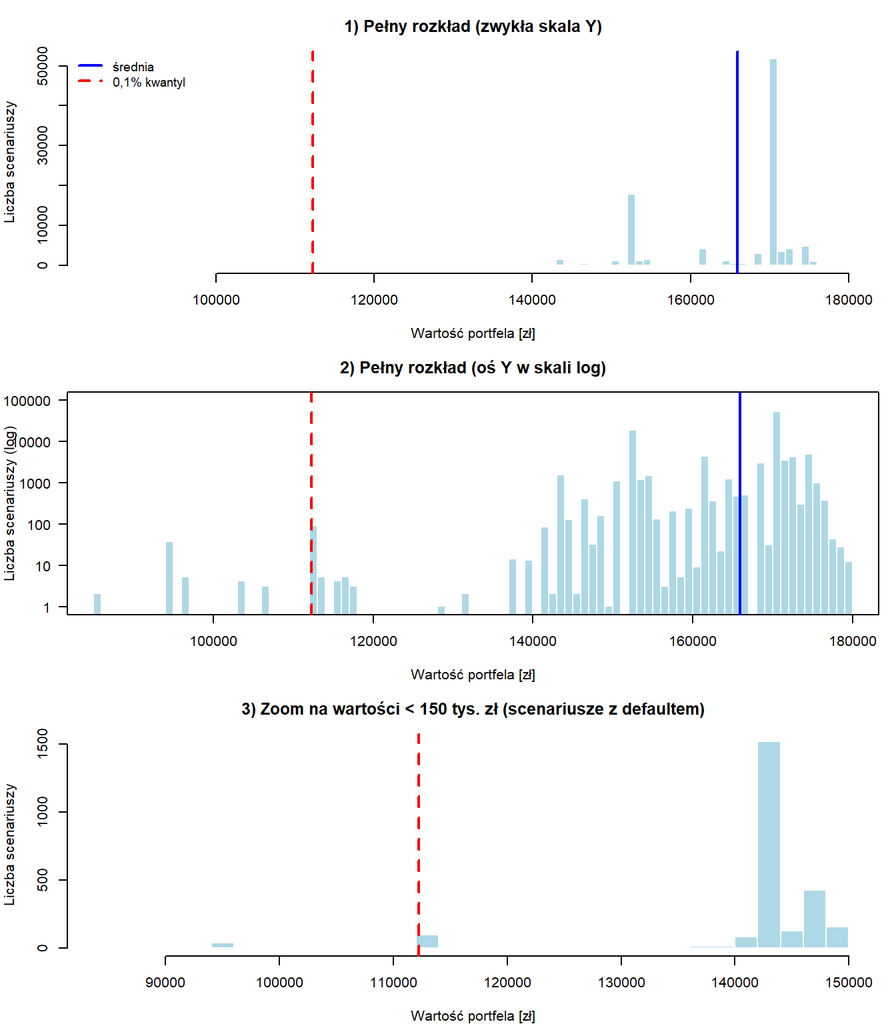

```r
# trzy wykresy jeden pod drugim
par(mfrow = c(3, 1), mar = c(4, 4, 3, 1))

# 1) pełny rozkład na zwykłej skali (oryginalny wygląd)
hist(wart_bez_kor, breaks = 120,
     main = "1) Pełny rozkład (zwykła skala Y)",
     xlab = "Wartość portfela [zł]",
     ylab = "Liczba scenariuszy",
     col = "lightblue", border = "white")

abline(v = sr_bez_kor, col = "blue", lwd = 2)
abline(v = kw_bez_kor, col = "red",  lwd = 2, lty = 2)

legend("topleft",
       legend = c("średnia", "0,1% kwantyl"),
       col = c("blue","red"), lty = c(1,2), lwd = 2, bty = "n", cex = 0.9)

# 2) pełny rozkład na skali LOG-Y (widać i pik, i rzadkie ogony)
h_out <- hist(wart_bez_kor, breaks = 80, plot = FALSE)


plot(h_out$mids, h_out$counts, type = "h", log = "y",
     main = "2) Pełny rozkład (oś Y w skali log)",
     xlab = "Wartość portfela [zł]",
     ylab = "Liczba scenariuszy (log)",
     col = "lightblue", lwd = 5, lend = 1,
     ylim = c(1, 1e5), yaxt = "n")

# etykiety osi Y
axis(2, at = c(1, 10, 100, 1000, 10000, 100000),
     labels = c("1", "10", "100", "1000", "10000", "100000"), las = 1)

abline(v = sr_bez_kor, col = "blue", lwd = 2)
abline(v = kw_bez_kor, col = "red",  lwd = 2, lty = 2)

# 3) zoom na niskie wartości (< 150 000 zł) -> tam leżą scenariusze z defaultem
ogon <- wart_bez_kor[wart_bez_kor < 150000]
hist(ogon, breaks = 40,
     main = "3) Zoom na wartości < 150 tys. zł (scenariusze z defaultem)",
     xlab = "Wartość portfela [zł]",
     ylab = "Liczba scenariuszy",
     col = "lightblue", border = "white")

abline(v = kw_bez_kor, col = "red", lwd = 2, lty = 2)
```

```r
par(mfrow = c(1, 1))
```

Rozkład wartości portfela nie jest gładką krzywą, tylko zbiorem pojedynczych wysokich słupków. Wynika to z tego, że dla 3 obligacji i 8 możliwych ratingów końcowych mamy **tylko 8³ = 512 kombinacji wartości portfela**. Każda kombinacja daje konkretną kwotę w zł, więc przy 100 000 symulacji te same wartości powtarzają się tysiące razy i tworzą pionowe “piki”.

**Wykres 1 (zwykła skala):** widać dwa wyraźne piki:

- **Najwyższy pik ~170–172 tys. zł**: to najbardziej prawdopodobny scenariusz: wszystkie trzy obligacje zostają w swoich startowych ratingach. Skąd to wiadomo? Policzmy z macierzy przejścia: P(BBB→BBB) · P(B→B) · P(CCC→CCC) = 0,8848 x 0,8422 x 0,692 ≈ **0,516**, czyli ok. 51,6% wszystkich losowań trafia na tę jedną kombinację, stąd tak wysoki pik.
- **Drugi, mniejszy pik ~150–155 tys. zł**: głównie scenariusze, w których CCC zbankrutowała, a pozostałe dwie obligacje zostały w startowym ratingu.

**Wykres 2 (skala log-Y):** oś Y jest logarytmiczna, każde kolejne “piętro” oznacza **10x więcej scenariuszy** (1, 10, 100, 1000, 10 000, 100 000). Dzięki temu na jednym obrazku widać zarówno najwyższy pik, jak i bardzo małe słupki (po 1–100 scenariuszy), które na zwykłej skali ginęły.

Co widać:

- **Najwyższy pik ~170–172 tys. zł**: wszystkie obligacje zostają w swoich startowych ratingach (jak wyżej).
- **Drugi duży pik ~150–155 tys. zł**: scenariusze z defaultem CCC. W macierzy przejścia P(CCC → Default) = **24,05%**, więc na 100 000 losowań ok. **24 tys. scenariuszy** ma CCC w defaulcie, stąd ten duży drugi pik.
- **Pojedyncze niskie słupki poniżej 120 tys. zł** (po 1–100 scenariuszy): najrzadsze scenariusze, w których zbankrutowała obligacja BBB lub B, albo kilka obligacji naraz. Widać je tylko dzięki skali log.

**Wykres 3 (zoom na wartości < 150 tys. zł):**

Czerwona przerywana linia (0,1% kwantyl ≈ 112 tys. zł) oddziela najgorsze 0,1% scenariuszy = to one wyznaczają VaR i ES.

**Wniosek z wykresów:** wartości portfela nie rozkładają się symetrycznie wokół średniej. W górę sięgają maksymalnie do ok. 180 tys. zł (ok. 14 tys. powyżej średniej 166 tys.), a w dół schodzą nawet do ok. 85 tys. zł (ok. 80 tys. poniżej średniej).

Tą asymetrie widać to wprost z tabeli wyceny obligacji z Kroku 1. Np. obligacja BBB:

- w startowym ratingu BBB warta jest **91 276 zł**,
- awans do najlepszego ratingu AAA daje **92 154 zł** (zysk tylko ~880 zł),
- default oznacza spadek do **32 740 zł** (strata ~58 500 zł).

Czyli najlepszy scenariusz podnosi wartość BBB o niecały tysiąc zł, a default zrzuca ją o prawie 60 tys. zł. Ta asymetria wyceny przenosi się na cały portfel, stąd rozciągnięty ogon w dół i zwarta masa w okolicach średniej.

## 3.5 Wariant z korelacją

Zakładam teraz, że zmiany ratingów obligacji są ze sobą powiązane (skorelowane), czyli pogorszenie jednej obligacji zwiększa szansę, że pogorszą się też pozostałe. Macierz korelacji:

$r_{12} = 0{,}2$, $r_{13} = 0{,}15$, $r_{23} = 0{,}4$.

```r
# macierz korelacji z treści zadania: r12=0.2, r13=0.15, r23=0.4
# przekątna = 1 (każda obligacja w pełni skorelowana sama ze sobą)
mac_kor <- matrix(c(
  1.00, 0.20, 0.15,
  0.20, 1.00, 0.40,
  0.15, 0.40, 1.00
), nrow = 3, byrow = TRUE)
mac_kor
```

```
##      [,1] [,2] [,3]
## [1,] 1.00  0.2 0.15
## [2,] 0.20  1.0 0.40
## [3,] 0.15  0.4 1.00
```

**Macirze:** tabela 3×3 ze współczynnikami korelacji między trzema obligacjami w portfelu:

- Pozycja [1,2] = 0,20 -> korelacja między obligacją BBB a obligacją B.
- Pozycja [1,3] = 0,15 -> korelacja między obligacją BBB a obligacją CCC.
- Pozycja [2,3] = 0,40 -> korelacja między obligacją B a obligacją CCC.
- Przekątna (1,00) -> każda obligacja jest w pełni skorelowana sama ze sobą (to zawsze prawda).
- Macierz jest **symetryczna** (korelacja X z Y = korelacja Y z X), dlatego te same liczby występują nad i pod przekątną.

Wszystkie korelacje są **dodatnie**, co znaczy, że nasze obligacje mają tendencję “pogarszać się razem” -> najsilniej para B <-> CCC (0,40).

```r
set.seed(42)

# symuluję portfel z korelacją (funkcja symuluj_portfel wykorzystuje
# dekompozycję Choleskiego do generowania skorelowanych wektorów N(0,1))
wart_kor <- symuluj_portfel(N, mac_kor)

# liczę te same miary ryzyka, co w wariancie bez korelacji
sr_kor   <- mean(wart_kor)
odch_kor <- sd(wart_kor)
kw_kor   <- quantile(wart_kor, 0.001)
VaR_kor  <- sr_kor - kw_kor
ES_kor   <- sr_kor - mean(wart_kor[wart_kor <= kw_kor])

data.frame(
  miara = c("Średnia wartość portfela",
            "Odchylenie standardowe",
            "0,1% kwantyl",
            "99,9% VaR",
            "99,9% ES"),
  wartosc = c(sr_kor, odch_kor, kw_kor, VaR_kor, ES_kor)
)
```

```
##                      miara wartosc
## 1 Średnia wartość portfela  165925
## 2   Odchylenie standardowe    9201
## 3             0,1% kwantyl  112251
## 4                99,9% VaR   53673
## 5                 99,9% ES   62631
```

Te same 5 miar ryzyka co wcześniej, tylko policzone dla wariantu **z korelacją**:

- **Średnia ≈ 165 925 zł**: oczekiwana wartość portfela po roku.
- **Odchylenie standardowe ≈ 9 201 zł**: typowe odchylenie wartości od średniej.
- **0,1% kwantyl ≈ 112 251 zł**: granica 100 najgorszych scenariuszy z 100 000.
- **99,9% VaR ≈ 53 673 zł**: maksymalna strata (względem średniej), której nie przekraczamy w 99,9% scenariuszy.
- **99,9% ES ≈ 62 631 zł**: przeciętna strata w 0,1% najgorszych scenariuszy.

### 3.5.1 Porównanie obu wariantów

```r
# tabela zestawiająca wyniki z obu wariantów (bez i z korelacją)
porownanie <- data.frame(
  miara = c("Średnia", "Odchylenie std.", "0,1% kwantyl",
            "99,9% VaR", "99,9% ES"),
  `bez korelacji` = c(sr_bez_kor, odch_bez_kor, kw_bez_kor,
                      VaR_bez_kor, ES_bez_kor),
  `z korelacją`   = c(sr_kor, odch_kor, kw_kor,
                      VaR_kor, ES_kor),
  check.names = FALSE
)

# dodaję kolumnę ze zmianą (różnica: z korelacją - bez korelacji)
porownanie$`zmiana [zł]` <- porownanie$`z korelacją` - porownanie$`bez korelacji`

porownanie
```

```
##             miara bez korelacji z korelacją zmiana [zł]
## 1         Średnia        165908      165925       16.45
## 2 Odchylenie std.          8618        9201      583.32
## 3    0,1% kwantyl        112251      112251        0.00
## 4       99,9% VaR         53657       53673       16.45
## 5        99,9% ES         59608       62631     3023.47
```

Zestawienie obok siebie wyników z dwóch wariantów: bez korelacji (Krok 3) i z korelacją (powyższa symulacja). Ostatnia kolumna “**zmiana [zł]**” = (z korelacją) − (bez korelacji) i pokazuje, o ile zmieniła się każda miara po dodaniu korelacji:

- Średnia: **+16 zł** (praktycznie bez zmian).
- Odchylenie std.: **+583 zł** (rozrzut wartości portfela wzrósł).
- 0,1% kwantyl: **0 zł** (granica najgorszych scenariuszy identyczna).
- 99,9% VaR: **+16 zł** (prawie bez zmian).
- 99,9% ES: **+3 023 zł** (tu efekt korelacji widać najmocniej).

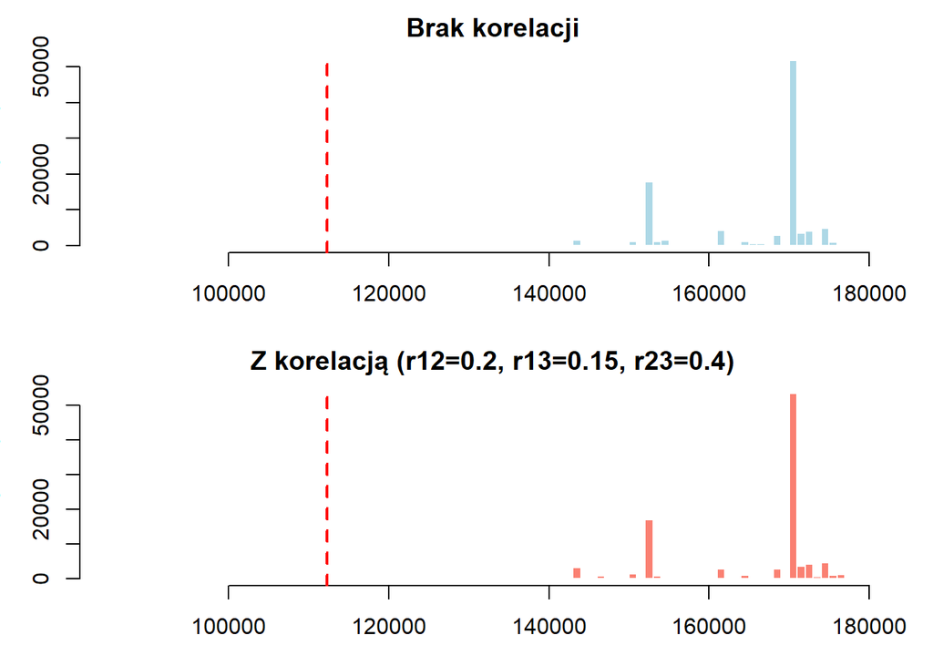

```r
par(mfrow = c(2,1), mar = c(3,3,2,1))

# histogram 1: wariant bez korelacji (jasnoniebieski)
hist(wart_bez_kor, breaks = 120, xlim = range(c(wart_bez_kor, wart_kor)),
     main = "Brak korelacji", xlab = "", col = "lightblue", border = "white")

# czerwona linia = 0,1% kwantyl w wariancie bez korelacji
abline(v = kw_bez_kor, col = "red", lty = 2, lwd = 2)

# histogram 2: wariant z korelacją (łososiowy, ten sam zakres osi x)
hist(wart_kor, breaks = 120, xlim = range(c(wart_bez_kor, wart_kor)),
     main = "Z korelacją (r12=0.2, r13=0.15, r23=0.4)",
     xlab = "Wartość portfela [zł]", col = "salmon", border = "white")

# czerwona linia = 0,1% kwantyl w wariancie z korelacją
abline(v = kw_kor, col = "red", lty = 2, lwd = 2)
```

```r
par(mfrow = c(1,1))
```

### 3.5.2 Interpretacja wyników w kontekście dywersyfikacji ryzyka

**Jak to łączy się z dywersyfikacją ryzyka?**

**Dywersyfikacja ryzyka** polega na trzymaniu w portfelu różnych obligacji, które nie zachowują się tak samo. Jeśli obligacje są słabo powiązane (niska korelacja), to gdy jedna ma zły okres, pozostałe często radzą sobie normalnie i ich straty nie sumują się, ryzyko całego portfela jest wtedy mniejsze niż suma ryzyk pojedynczych obligacji.

W naszym wariancie z korelacją współczynniki są **dodatnie** (r₁₂ = 0,2, r₁₃ = 0,15, r₂₃ = 0,4), czyli obligacje mają tendencję pogarszać się razem. Wtedy dywersyfikacja działa słabiej: straty częściej pojawiają się jednocześnie i ich suma robi się większa. To właśnie dlatego miary ryzyka (zwłaszcza ES) są wyższe w wariancie z korelacją, mimo że średnia wartość portfela pozostaje taka sama.

W praktyce oznacza to, że jeśli inwestor chce mieć **niższe ryzyko**, powinien dobierać do portfela obligacje **różnych branż i regionów**, wtedy korelacje są niskie, a dywersyfikacja działa skuteczniej.

# 4 Metody szacowania korelacji w modelu CreditMetrics

Policzenie macierzy korelacji między obligacjami to jeden z najtrudniejszych elementów modelu CreditMetrics. Dokumentacja techniczna opisuje **cztery sposoby**, w jakie można to zrobić.

## 4.1 Bezpośrednie szacowanie korelacji z historii migracji ratingów

Najbardziej intuicyjne podejście polega na analizie szeregów historycznych ratingów wielu firm jednocześnie. Dysponując bazą zawierającą kwartalne ratingi kilku tysięcy emitentów w długim okresie, możemy bezpośrednio policzyć, jak często dwie konkretne firmy o danych ratingach początkowych wspólnie migrowały do różnych ratingów końcowych, i na tej podstawie zbudować empiryczną tabelę wspólnych prawdopodobieństw migracji dla par firm.

## 4.2 Szacowanie korelacji poprzez spready obligacyjne

Drugi sposób wykorzystuje **historyczne ceny obligacji**: kiedy rating firmy się pogarsza, cena jej obligacji spada (bo inwestorzy uznają, że firma jest bardziej ryzykowna). Więc jeśli ceny obligacji dwóch firm wahają się razem, to można z tego wyciągnąć, że zmiany ich ratingów też są ze sobą powiązane.

Postępuje się tak:

1. Z ceny obligacji wyliczamy **spread kredytowy**, czyli o ile oprocentowanie obligacji firmy jest wyższe niż oprocentowanie bezpiecznej obligacji skarbowej o tym samym terminie (ta różnica to premia za ryzyko: im większe ryzyko, tym większy spread).
2. Liczymy, jak spready różnych firm zmieniają się razem, czyli ich korelację.
3. Za pomocą dodatkowego modelu (np. modelu Duffee’a albo Nielsen-Ronna) zamieniamy korelację spreadów na korelację zmian ratingów.

**Problem tej metody**: dane o cenach obligacji firmowych są słabo dostępne, a już zwłaszcza dla firm o słabym ratingu. Przez to w praktyce trudno tę metodę zastosować.

## 4.3 Model wartości aktywów (*asset value model*)

To **metoda standardowo stosowana w CreditMetrics**, oparta na idei **modelu Mertona**. Pomysł jest taki: zmiana ratingu firmy zależy od tego, co dzieje się z **wartością jej aktywów**. Jeśli wartość aktywów mocno spadnie, firma zmieni rating na gorszy albo zbankrutuje. Jeśli wartość wzrośnie, rating może awansować.

W modelu zakłada się, że **stopa zwrotu z aktywów** (czyli o ile procent wartość aktywów firmy urosła lub spadła w ciągu roku) ma standardowy rozkład normalny $N(0,1)$. Na podstawie macierzy przejścia wyznaczamy na tej osi progi, które oddzielają kolejne ratingi (dokładnie tak samo jak w Kroku 2 naszej symulacji).

**Po co to komu?** Zamiast próbować liczyć wprost korelację między ratingami dwóch firm (co jest trudne, bo defaulty są rzadkie), liczymy **korelację między ich stopami zwrotu z aktywów**. Taką korelację dużo łatwiej oszacować, a daje ten sam efekt w modelu.

**Najprostszy wariant**: przyjmujemy jedną, stałą wartość korelacji dla wszystkich par obligacji w portfelu. Dokumentacja podaje, że dla dużego portfela firmowego typowa wartość to **20%–35%**.

## 4.4 Szacowanie korelacji aktywów na podstawie indeksów giełdowych

Powyższe podejście jest dokładniejsze, jeśli uwzględniamy **specyfikę branżową i geograficzną** każdego emitenta. Ponieważ bezpośrednia obserwacja stóp zwrotu z aktywów firmy jest niemożliwa (tak jak w modelu Mertona), CreditMetrics proponuje wykorzystać **stopy zwrotu z akcji** jako przybliżenie (proxy) dla stóp zwrotu z aktywów.

Procedura składa się z dwóch etapów:

1. Na podstawie indeksów branżowych w poszczególnych krajach budujemy macierz korelacji **między branżami w danych krajach** (np. korelacja między niemieckim przemysłem chemicznym a amerykańskim sektorem ubezpieczeniowym). Dla każdego indeksu zapisujemy też jego zmienność.
2. Każdego emitenta **mapujemy** na odpowiednie wagi branżowo-krajowe (np. firma 80% niemiecka i 20% amerykańska, 70% chemia i 30% finanse, co daje 56% niemieckiej chemii, 24% niemieckich finansów, 14% amerykańskiej chemii i 6% amerykańskich finansów). Korelacje między parami emitentów wyliczamy z tych wag i macierzy korelacji indeksów.

Dzięki temu możemy policzyć korelację dla dowolnej liczby firm bez potrzeby trzymania olbrzymiej tabeli ze wszystkimi parami (wystarczy mała macierz korelacji między branżami i krajami). Dodatkowo metoda uwzględnia, z jakiej branży i z jakiego kraju pochodzi każda firma, więc jest **dokładniejsza** niż podejście z jedną stałą wartością korelacji (20%–35%).

# 5 Podsumowanie

Wyznaczenie ryzyka kredytowego portfela trzech obligacji metodą CreditMetrics dało następujące wyniki 99,9% VaR i ES. Horyzont obliczeń to **1 rok** (wynika to z naszej macierzy przejścia, która jest jednoroczna, oraz z funkcji `wycena_po_roku` w Kroku 1). Liczba symulacji Monte Carlo: N = 100 000.

```r
podsum <- data.frame(
  wariant = c("Brak korelacji", "Z korelacją (0,2 / 0,15 / 0,4)"),
  `VaR 99.9%` = c(VaR_bez_kor, VaR_kor),
  `ES 99.9%`  = c(ES_bez_kor, ES_kor),
  check.names = FALSE
)
podsum
```

```
##                          wariant VaR 99.9% ES 99.9%
## 1                 Brak korelacji     53657    59608
## 2 Z korelacją (0,2 / 0,15 / 0,4)     53673    62631
```

Z tabeli widać, że dodatnie korelacje **zwiększają miary ryzyka**, a najmocniej **ES** (z 59 608 zł do 62 631 zł, czyli o ok. 3 tys. zł). Dzieje się tak, bo gdy obligacje są ze sobą powiązane, częściej zdarzają się scenariusze, w których kilka z nich pogarsza się jednocześnie. Praktyczny wniosek: **dywersyfikacja** portfela między różne branże i regiony zmniejsza te skumulowane straty, nie zmieniając średniej wartości portfela.

Z dokumentacji technicznej wynika, że samo oszacowanie korelacji jest jednym z najtrudniejszych elementów modelu. W praktyce najczęściej stosuje się **model wartości aktywów** (asset value model) razem z mapowaniem firm na indeksy branżowo-krajowe, bo ta metoda daje najlepszy kompromis między dokładnością a możliwością policzenia wyników dla dużych portfeli.